# Lecture 7 R Practice

SANG JIN LEE

2024-05-13

```r
library(tidyverse)
library(ggplot2)
library(DescTools)
```

### 다음의 데이터는 2020년에 보고된 153개의 국가의 국민 행복도 지수(Score)와 1인당 국내 총생산(GDP.per.capita)이다.

```r
dat <- read.csv("worldbank2020.csv")[,3:4]
n = nrow(dat)
head(dat)
```

```
##   Score GDP.per.capita
## 1 7.809          1.285
## 2 7.646          1.327
## 3 7.560          1.391
## 4 7.504          1.327
## 5 7.488          1.424
## 6 7.449          1.339
```

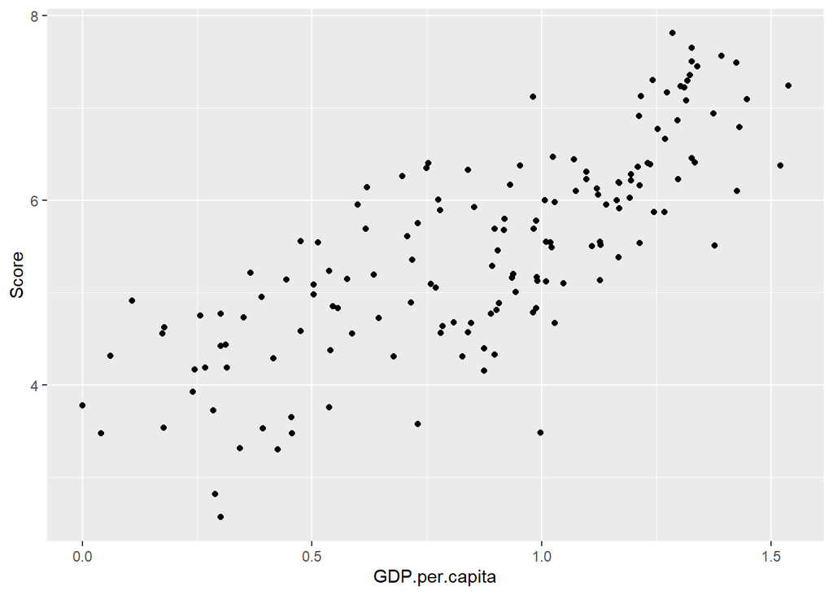

```r
dat %>% arrange(Score)  %>%
  ggplot(aes(GDP.per.capita, Score)) + geom_point()
```

```r
r = cor(dat[,1], dat[,2])
round(r, 3)
```

```
## [1] 0.775
```

### The distribution of $Z=\frac{1}{2} \log(\frac{1+r}{1-r})$ can be approximated by a normal distribution with mean $\frac{1}{2} \log(\frac{1+\rho}{1-\rho})$ and variance 1/(n-3).

```r
z = DescTools::FisherZ(r) # same as (1/2)*log((1+r)/(1-r))

# Asymptotic CI for normal population
CI.tr = DescTools::FisherZInv( z + qnorm(c(0.025, 1-0.025))/sqrt(n-3) )
CI.tr
```

```
## [1] 0.7031018 0.8316518
```

## Nonparametric bootstrap

```r
set.seed(2020)
B = 1999 # number of bootstrap samples
C = 25   # number of second-level boostrap samples

r.boot = replicate(B, {
  boot.id = sample(1:n,n, replace = TRUE)

  r = cor(dat[boot.id,1], dat[boot.id,2])

  # second-level bootstrap
  r2.boot = replicate(C, {
    boot.id2 = sample(boot.id,n, replace = TRUE)
    cor(dat[boot.id2,1], dat[boot.id2,2])
  })
  r.se = sd(r2.boot)

  c(r,r.se)
})

r.boot = t(r.boot)
colnames(r.boot) = c("r*","sd(r*)")
r.boot = as.data.frame(r.boot)
head(r.boot)
```

```
##          r*     sd(r*)
## 1 0.7285066 0.02165156
## 2 0.7460809 0.02965767
## 3 0.7431098 0.02780840
## 4 0.7686081 0.03584860
## 5 0.7994594 0.02366014
## 6 0.7731021 0.03538221
```

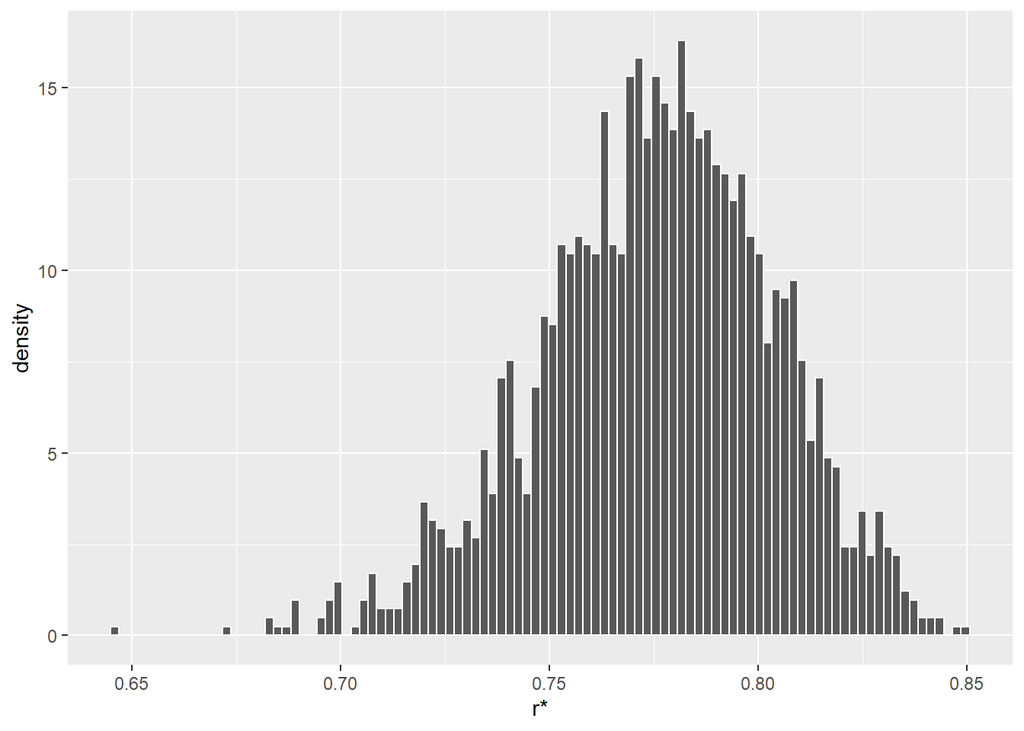

```r
# Bootstrap distribution of r
r.boot %>%
  ggplot(aes(x = `r*`)) +
  geom_histogram(aes(y = ..density..), color = "white",bins = 100)
```

```r
r = cor(dat[,1],dat[,2])
r.vec = c(r, sd(r.boot$`r*`))
names(r.vec) = c("r","se(r)")
r.vec
```

```
##         r     se(r)
## 0.7752839 0.0281011
```

### 1) Bootstrap-t method

The $b^{\text{th}}$ bootstrap t-pivot quantity is $t^{(b)} = \frac{\hat{\theta}^{(b)}-\hat{\theta}}{\hat{se}(\hat{\theta}^{(b)})}$.

The estimate $\hat{se}(\hat{\theta}^{(b)})$ is obtained from second-level bootstrap samples.

95% CI: $\hat{\theta} - t_{b, 0.975} \times \hat{se}(\hat{\theta}) < \theta < \hat{\theta} - t_{b, 0.025} \times \hat{se}(\hat{\theta})$

```r
t.pivot = (r.boot$`r*` - r.vec[1]) / r.boot$`sd(r*)`
(CI.t = r.vec[1] - r.vec[2] * quantile(t.pivot, probs = c(1-0.025, 0.025)))
```

```
##     97.5%      2.5%
## 0.7004666 0.8266646
```

### 2) Percentile method

95% CI: $\hat{\theta}_{b, 0.025} < \theta < \hat{\theta}_{b, 0.975}$

```r
(CI.pct = quantile(r.boot$`r*`, probs = c(0.025, 1-0.025)))
```

```
##      2.5%     97.5%
## 0.7176703 0.8279265
```

### 3) Residual method

The $b^{\text{th}}$ bootstrap residual is $\epsilon^{(b)} = \hat{\theta}^{(b)} - \hat{\theta}$.

95% CI: $\hat{\theta}-\epsilon_{b, 0.975} < \theta < \hat{\theta}-\epsilon_{b, 0.025}$, or equivalently, $2\hat{\theta} - \hat{\theta}_{b, 0.975} < \theta < 2\hat{\theta} - \hat{\theta}_{b, 0.025}$

```r
(CI.resid = 2*r.vec[1] - quantile(r.boot$`r*`, probs = c(1-0.025, 0.025)))
```

```
##     97.5%      2.5%
## 0.7226414 0.8328976
```

### 4) Bias-corrected and accelerated (BCa) method

Estimating bias-correction factor:

$\hat{z}_0 = \Phi^{-1}\{\frac{1}{B} \sum_{b=1}^{B} I(\hat{\theta}^{(b)}<\hat{\theta})\}$

```r
b.factor = qnorm( sum(r.boot$`r*` <= r.vec[1])/(B+1))
b.factor
```

```
## [1] -0.06647457
```

Estimating acceleration factor:

$\hat{a} = \frac{\sum_{i=1}^{n} ( \hat{\theta}_{(.)} - \hat{\theta}_{(i)} )^3}{6\{ \sum_{i=1}^{n} ( \hat{\theta}_{(.)} - \hat{\theta}_{(i)} )^2 \}^{3/2} }$

```r
r.jack = vector(length = n)
for (i in 1:n){r.jack[i] =  cor(dat[-i,1], dat[-i,2]) }
acc = sum((r.jack- mean(r.jack))^3) / (6*sum((r.jack- mean(r.jack))^2)^(3/2))
acc
```

```
## [1] 0.01559328
```

95% CI: $\hat{\theta}_{b, \Phi(z_L)} < \theta < \hat{\theta}_{b, \Phi(z_U)}$

where $Z_L = \frac{\hat{z}_0 - z_{0.975}} {1-\hat{a}(\hat{z}_0 - z_{0.975})} + \hat{z}_0$ and $Z_U = \frac{\hat{z}_0 + z_{0.975}} {1-\hat{a}(\hat{z}_0 + z_{0.975})} + \hat{z}_0$.

```r
bz = b.factor + qnorm( c(0.025, 1-0.025) )
int.probs = pnorm( (bz)/(1 - acc*(bz)) + b.factor )
(CI.BCa = quantile(r.boot$`r*`, probs = int.probs))
```

```
## 2.113554% 97.02596%
## 0.7138295 0.8256577
```

```r
# collect all and compare
CIs = rbind(CI.tr, CI.t, CI.pct, CI.resid, CI.BCa)
colnames(CIs) = c("lower", "upper")
CIs = as.data.frame(CIs) %>% mutate(width=upper-lower)
round(CIs, 3)
```

```
##          lower upper width
## CI.tr    0.703 0.832 0.129
## CI.t     0.700 0.827 0.126
## CI.pct   0.718 0.828 0.110
## CI.resid 0.723 0.833 0.110
## CI.BCa   0.714 0.826 0.112
```